# Prädiktion der koronaren Herzkrankheit (KHK)

Statistische Modellierung und Entwicklung eines Screening-Tools

2026-03-12

# 1 Einleitung & Forschungsfrage

In der klinischen Praxis stellt die Erstdiagnostik eine erhebliche Herausforderung dar. Die definitive Bestätigung oder der Ausschluss einer KHK erfordert oft ressourcenintensive, teure oder invasive Verfahren, wie beispielsweise die Myokard-Szintigraphie, das Stress-MRT oder die invasive Koronarangiographie (Herzkatheter). Da diese Verfahren nicht flächendeckend als Erstlinientest eingesetzt werden können, kommt der Primärversorgung (Hausarztpraxis) eine essenzielle Triage- und Gatekeeper-Funktion zu. Es bedarf effizienter Entscheidungshilfen, um Patienten mit unklaren Brustschmerzen schnell und sicher anhand leicht erhebbarer Basisparameter in entsprechende Risikogruppen einzuteilen.

Vor diesem medizinischen und gesundheitsökonomischen Hintergrund leitet sich die zentrale Forschungsfrage dieser Arbeit ab: Mit welcher diagnostischen Genauigkeit lässt sich das Vorliegen einer koronaren Herzkrankheit durch physiologische und klinische Parameter vorhersagen?

Um diese Frage zu beantworten, verfolgt die vorliegende Arbeit ein zweistufiges Ziel: Im ersten Schritt wird anhand des historischen “Cleveland Heart Disease”-Datensatzes ein statistisch optimiertes Klassifikationsmodell (logistische Regression) entwickelt und mit modernen Machine-Learning-Verfahren (Random Forest) verglichen. Im zweiten Schritt liegt der Fokus auf der praktischen Translation: Ziel ist es, aus den statistischen Erkenntnissen ein praxistaugliches, reduziertes Screening-Tool zu extrahieren. Dieses soll ausschliesslich auf non-invasiven Basisparametern beruhen und sich an den aktuellen Triage-Leitlinien der European Society of Cardiology (ESC) orientieren. Das finale Modell wird schliesslich in einen Prototyp eines interaktiven Clinical Decision Support Systems (CDSS) überführt, um medizinisches Personal bei der evidenzbasierten Entscheidungsfindung zu unterstützen.

# 2 Datengrundlage & Datenaufbereitung (Preprocessing)

Für die vorliegende Analyse wurde der renommierte “Cleveland Heart Disease”-Datensatz aus dem UCI Machine Learning Repository herangezogen. Ursprünglich umfasste der Datensatz n = 303 Beobachtungen klinischer Patientendaten. Im Rahmen eines rigorosen Preprocessings wurden die Daten zunächst auf Inkonsistenzen und fehlende Werte (im Originaldatensatz teilweise als “?” kodiert) geprüft. Um Verzerrungen in den späteren Machine-Learning-Modellen zu vermeiden, wurden sechs unvollständige Fälle vollständig aus dem Datensatz entfernt (Listwise Deletion). Die finale, bereinigte Stichprobe für die Modellierung beläuft sich somit auf n = 297 Patienten.

Ein zentraler methodischer Schritt der Datenaufbereitung war die Transformation der abhängigen Zielvariable `num`. Im Originaldatensatz gibt diese den angiografischen Schweregrad der koronaren Herzkrankheit auf einer Skala von 0 (keine Gefässverengung) bis 4 (schwere Mehrgefässerkrankung) an. Für die Zwecke dieser Arbeit wurde diese multikategoriale Variable in eine binäre Klassifikation überführt: Der Wert 0 wurde als “gesund” (Klasse 0) beibehalten, während sämtliche Ausprägungen von 1 bis 4 unter der Klasse “krank” (Klasse 1) zusammengefasst wurden.

Diese Binarisierung ist primär in der geringen Stichprobengrösse begründet. Der Versuch, ein prädiktives Modell für fünf separate Ausprägungen auf Basis von lediglich 297 Patienten zu trainieren, würde zu einer massiven Zersplitterung der Daten (Class Imbalance) und somit zu instabilen, statistisch nicht signifikanten Schätzern führen. Durch die Reduktion auf eine dichotome Fragestellung (Vorliegen einer KHK: ja oder nein) wird das Modell exakt auf die klinisch relevanteste Triage-Entscheidung fokussiert. Dies gewährleistet die nötige statistische Power und Robustheit für die nachfolgenden logistischen Regressions- und Machine-Learning-Verfahren.

### 2.0.1 Variablenübersicht (Codebook)

Der verwendete Cleveland-Datensatz umfasst nach der Bereinigung 14 klinisch relevante Attribute. Die folgende Tabelle bietet eine Übersicht über die verwendeten physiologischen Parameter, deren Bedeutung sowie ihre Ausprägungen:

| Variable | Beschreibung | Ausprägungen / Datentyp |
| --- | --- | --- |
| **`age`** | Alter der Patienten | Kontinuierlich (in Jahren) |
| **`sex`** | Geschlecht | Binär (1 = Männlich, 0 = Weiblich) |
| **`cp`** | Brustschmerztyp (*Chest Pain*) | Kategorial (1 = typische Angina, 2 = atypische Angina, 3 = nicht-anginöser Schmerz, 4 = asymptomatisch) |
| **`trestbps`** | Ruheblutdruck bei Klinikaufnahme | Kontinuierlich (in mm Hg) |
| **`chol`** | Serumcholesterin | Kontinuierlich (in mg/dl) |
| **`fbs`** | Nüchternblutzucker > 120 mg/dl | Binär (1 = Ja, 0 = Nein) |
| **`restecg`** | Ruhe-EKG-Ergebnisse | Kategorial (0 = normal, 1 = ST-T-Wellen-Anomalie, 2 = wahrscheinliche/definitive Linksherzhypertrophie) |
| **`thalach`** | Maximal erreichte Herzfrequenz | Kontinuierlich (Schläge pro Minute) |
| **`exang`** | Belastungsinduzierte Angina pectoris | Binär (1 = Ja, 0 = Nein) |
| **`oldpeak`** | ST-Senkung durch Belastung (relativ zur Ruhe) | Kontinuierlich |
| **`slope`** | Steigung des maximalen Belastungs-ST-Segments | Kategorial (1 = ansteigend, 2 = flach, 3 = abfallend) |
| **`ca`** | Anzahl der Hauptgefässe, gefärbt durch Fluoroskopie | Ordinal (0 bis 3) |
| **`thal`** | Thallium-Szintigraphie (Nuklearmedizin. Test) | Kategorial (3 = normal, 6 = fixierter Defekt, 7 = reversibler Defekt) |
| **`num` / `target`** | Diagnose der koronaren Herzkrankheit (Zielvariable) | Ursprünglich 0-4. Binarisiert: 0 = Gesund, 1 = Krank |

## 2.1 Datenbereinigung und Binarisierung

```r
# 1. Daten laden
heart_disease <- fetch_ucirepo(id = 45)
df <- bind_cols(heart_disease$data$features, heart_disease$data$targets)

# 2. Fehlerhafte Werte (?) mit echtem NA ersetzen und Typen korrigieren
df[df == "?"] <- NA
df$ca <- as.numeric(as.character(df$ca))
df$thal <- as.numeric(as.character(df$thal))

# 3. Zielvariable binarisieren (0 = Gesund, 1 = Krank) und 'num' entfernen
df_modell <- df %>%
  mutate(target = as.factor(ifelse(num > 0, "1", "0"))) %>%
  select(-num)

# 4. Rigoroses Löschen aller fehlenden Werte für sauberes Machine Learning
df_modell <- na.omit(df_modell)

# Kontrolle
dim(df_modell)
```

```
## [1] 297  14
```

# 3 Explorative Datenanalyse (EDA)

Um ein tiefgreifendes Verständnis für die zugrundeliegende Datenstruktur zu gewinnen und erste Hypothesen für die spätere prädiktive Modellierung abzuleiten, wurde eine umfassende explorative Datenanalyse (EDA) durchgeführt. Diese Evaluation stützt sich sowohl auf deskriptiv-visuelle als auch auf inferenzstatistische Methoden.

Zunächst wurden die kategorialen Variablen mittels Kreuztabellen und Pearson-Chi-Quadrat-Tests auf ihre stochastische Unabhängigkeit von der Zielvariable (KHK-Diagnose) geprüft. Hierbei zeigte sich ein hochsignifikanter Zusammenhang beim Brustschmerztyp (`cp`, p < 0.001). Auch das Geschlecht (`sex`) wies einen statistisch hochsignifikanten Einfluss auf die Verteilung der Herzerkrankungen auf (p < 0.001). Diese Parameter qualifizieren sich somit bereits in der univariaten Betrachtung als starke Prädiktoren.

Für die kontinuierlichen Variablen wurden Varianzanalysen (ANOVA) durchgeführt, um signifikante Mittelwertunterschiede zwischen der gesunden Kontrollgruppe und den erkrankten Patienten zu identifizieren. Die Ergebnisse belegen, dass sich erkrankte Patienten hinsichtlich ihres höheren Alters (`age`, p < 0.001), eines höheren Ruheblutdrucks (`trestbps`, p = 0.008) und insbesondere einer deutlich niedrigeren maximal erreichten Herzfrequenz unter Belastung (`thalach`, p < 0.001) signifikant von der gesunden Gruppe unterscheiden. Diese systematischen Abweichungen werden in den nachfolgenden Boxplots visuell unterstrichen.

Abschliessend wurde eine Korrelationsmatrix aller numerischen Variablen erstellt. Dieser methodische Prüfschritt ist essenziell, um potenzielle Multikollinearität – also zu starke Abhängigkeiten der Prädiktoren untereinander – frühzeitig zu erkennen. Eine ausgeprägte Multikollinearität (beispielsweise eine nahezu perfekte Korrelation zweier Variablen) könnte die Koeffizienten der späteren logistischen Regression verzerren und instabil machen. Die visuelle und rechnerische Inspektion der Matrix zeigt jedoch, dass die Korrelationen zwischen den unabhängigen Variablen in einem unkritischen Bereich liegen. Somit können alle Parameter methodisch sauber in das initiale Basismodell (Kapitel 4) aufgenommen werden.

## 3.2 Multikollinearität und Hypothesentests

```r
# --- EDA: Chi-Quadrat-Tests ---

# 1. Brustschmerztyp (cp) vs. Zielvariable (target)
# Erstelle zuerst eine Kreuztabelle (Wir nutzen jetzt df_modell!)
tabelle_cp <- table(df_modell$cp, df_modell$target)
# Führe den Test aus
test_cp <- chisq.test(tabelle_cp)
print(test_cp)
```

```
##
##  Pearson's Chi-squared test
##
## data:  tabelle_cp
## X-squared = 77.276, df = 3, p-value < 2.2e-16
```

```r
# 2. Geschlecht (sex) vs. Zielvariable (target)
tabelle_sex <- table(df_modell$sex, df_modell$target)
test_sex <- chisq.test(tabelle_sex)
print(test_sex)
```

```
##
##  Pearson's Chi-squared test with Yates' continuity correction
##
## data:  tabelle_sex
## X-squared = 21.852, df = 1, p-value = 2.946e-06
```

```r
# 1. Maximale Herzfrequenz (thalach) nach Zielvariable (target)
anova_thalach <- aov(thalach ~ target, data = df_modell)
summary(anova_thalach)
```

```
##              Df Sum Sq Mean Sq F value   Pr(>F)
## target        1  27983   27983   64.59 2.24e-14 ***
## Residuals   295 127806     433
## ---
## Signif. codes:  0 '***' 0.001 '**' 0.01 '*' 0.05 '.' 0.1 ' ' 1
```

```r
# 2. Alter (age) nach Zielvariable (target)
anova_age <- aov(age ~ target, data = df_modell)
summary(anova_age)
```

```
##              Df Sum Sq Mean Sq F value   Pr(>F)
## target        1   1250  1250.0   16.04 7.86e-05 ***
## Residuals   295  22992    77.9
## ---
## Signif. codes:  0 '***' 0.001 '**' 0.01 '*' 0.05 '.' 0.1 ' ' 1
```

```r
# 3. Ruheblutdruck (trestbps) nach Zielvariable (target)
anova_trestbps <- aov(trestbps ~ target, data = df_modell)
summary(anova_trestbps)
```

```
##              Df Sum Sq Mean Sq F value  Pr(>F)
## target        1   2200  2200.3   7.118 0.00805 **
## Residuals   295  91193   309.1
## ---
## Signif. codes:  0 '***' 0.001 '**' 0.01 '*' 0.05 '.' 0.1 ' ' 1
```

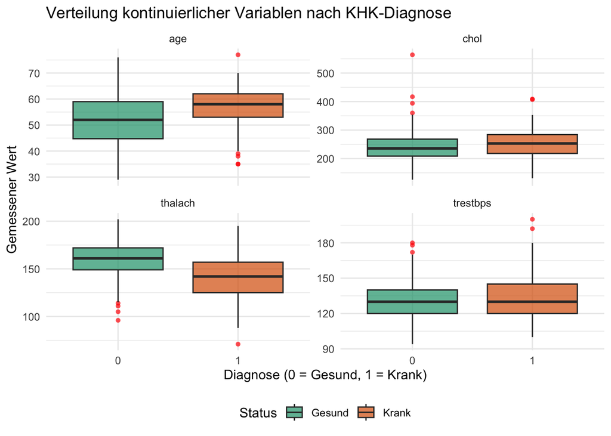

```r
# --- 1. VISUELLE EDA: Kontinuierliche Variablen (Boxplots) ---
plot_kontinuierlich <- df_modell %>%
  select(target, age, thalach, trestbps, chol) %>%
  pivot_longer(cols = -target, names_to = "Variable", values_to = "Wert") %>%
  ggplot(aes(x = target, y = Wert, fill = target)) +
  geom_boxplot(alpha = 0.7, outlier.colour = "red", outlier.shape = 16) +
  facet_wrap(~ Variable, scales = "free_y") +
  scale_fill_manual(values = c("0" = "#1b9e77", "1" = "#d95f02"),
                    labels = c("0" = "Gesund", "1" = "Krank")) +
  theme_minimal() +
  labs(title = "Verteilung kontinuierlicher Variablen nach KHK-Diagnose",
       x = "Diagnose (0 = Gesund, 1 = Krank)",
       y = "Gemessener Wert",
       fill = "Status") +
  theme(legend.position = "bottom")

print(plot_kontinuierlich)
```

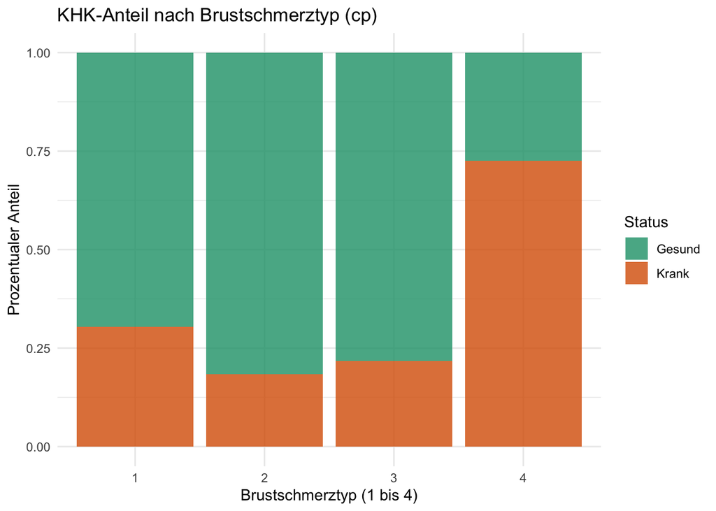

```r
# --- 2. VISUELLE EDA: Kategoriale Variablen (Gestapelte Balkendiagramme) ---

# Plot für Brustschmerztyp (cp)
plot_cp <- ggplot(df_modell, aes(x = factor(cp), fill = target)) +
  geom_bar(position = "fill", alpha = 0.8) +
  scale_fill_manual(values = c("0" = "#1b9e77", "1" = "#d95f02"),
                    labels = c("0" = "Gesund", "1" = "Krank")) +
  theme_minimal() +
  labs(title = "KHK-Anteil nach Brustschmerztyp (cp)",
       x = "Brustschmerztyp (1 bis 4)",
       y = "Prozentualer Anteil",
       fill = "Status")

print(plot_cp)
```

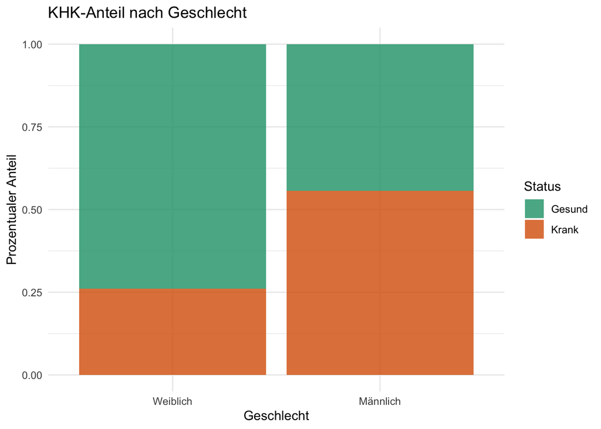

```r
# Plot für Geschlecht (sex)
plot_sex <- ggplot(df_modell, aes(x = factor(sex), fill = target)) +
  geom_bar(position = "fill", alpha = 0.8) +
  scale_fill_manual(values = c("0" = "#1b9e77", "1" = "#d95f02"),
                    labels = c("0" = "Gesund", "1" = "Krank")) +
  scale_x_discrete(labels = c("0" = "Weiblich", "1" = "Männlich")) +
  theme_minimal() +
  labs(title = "KHK-Anteil nach Geschlecht",
       x = "Geschlecht",
       y = "Prozentualer Anteil",
       fill = "Status")

print(plot_sex)
```

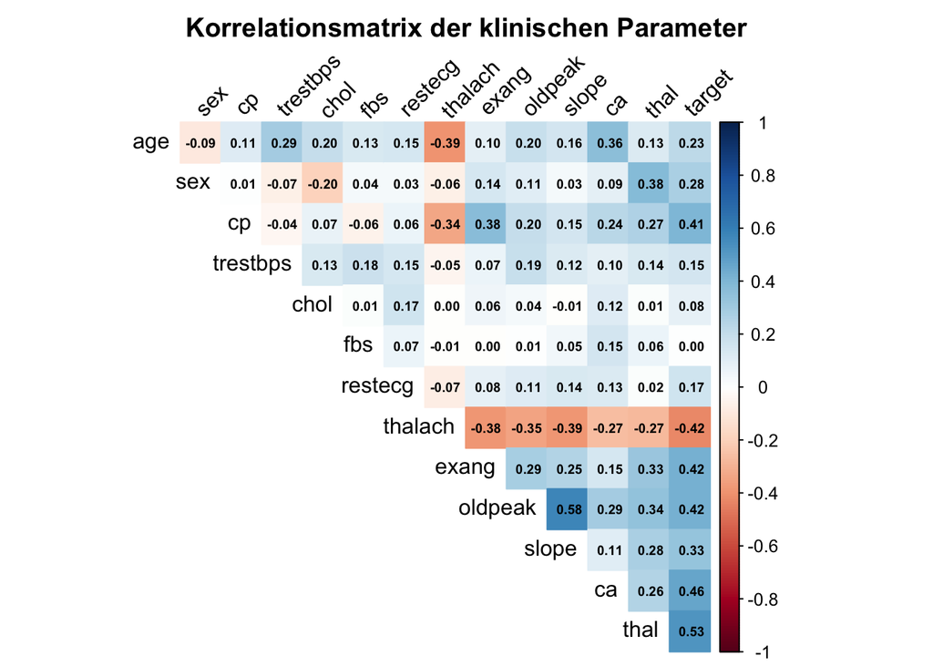

```r
# --- 3. VISUELLE EDA: Multikollinearität (Korrelationsmatrix) ---
df_numerisch <- df_modell %>%
  mutate(across(everything(), as.numeric))

# Korrelationsmatrix berechnen
korrelations_matrix <- cor(df_numerisch, use = "complete.obs")

# Matrix plotten
corrplot(korrelations_matrix,
         method = "color",
         type = "upper",
         addCoef.col = "black",
         number.cex = 0.6,
         tl.col = "black",
         tl.srt = 45,
         diag = FALSE,
         title = "Korrelationsmatrix der klinischen Parameter",
         mar = c(0,0,2,0))
```

# 4 Statistische Modellierung

Um ein belastbares prädiktives Modell zu erstellen, das auch auf neue, ungesehene Patientendaten generalisierbar ist, wurde der bereinigte Datensatz zunächst in ein Trainingsset (70 % der Beobachtungen, n = 207) und ein Testset (30 % der Beobachtungen, n = 90) aufgeteilt. Ein Seed (Random State) stellte hierbei sicher, dass dieser zufällige Split bei erneuter Ausführung exakt reproduzierbar bleibt. Die Modellierung selbst basiert auf dem Verfahren der multivariaten logistischen Regression, da die binarisierte Zielvariable (“Krank” vs. “Gesund”) dieses Vorgehen mathematisch zwingend erfordert.

Im ersten Schritt wurde ein vollständiges Basismodell geschätzt, welches alle 13 verfügbaren Prädiktoren in die Regression einschloss. Die statistische Auswertung (siehe Summary des vollen Modells) lieferte einen initialen Akaike-Informationskriterium (AIC)-Wert von 164.5. Der AIC-Wert dient als Mass für die relative Güte eines statistischen Modells; ein niedrigerer Wert indiziert eine bessere Balance zwischen der Anpassung an die Daten (Goodness of Fit) und der Komplexität des Modells (Anzahl der verwendeten Parameter).

**Interpretation des “Alters-Paradoxons”**

Besondere Beachtung verdient in diesem Kontext das Ausscheiden der Variable Alter (`age`). In der vorgeschalteten explorativen Datenanalyse (Kapitel 3) zeigte sich das Alter in der univariaten Betrachtung als hochsignifikanter Trennfaktor (p < 0.001) zwischen gesunden und kranken Patienten. In der multivariaten Regression hingegen verlor das Alter seine statistische Signifikanz (p = 0.825 im vollen Modell) und wurde bei der Optimierung eliminiert.

Dieses augenscheinliche Paradoxon lässt sich durch das Konzept der Multikollinearität und der konfundierenden Variablen erklären: Zwar steigt das Risiko für eine KHK mit dem Alter unbestritten an, jedoch manifestiert sich dieses Risiko physiologisch meist in anderen, direkt messbaren Parametern (wie einem höheren Ruheblutdruck `trestbps` oder einer zunehmenden Gefässverkalkung `ca`). Sobald diese direkten physiologischen “Treiber” der Krankheit im Modell enthalten sind, liefert das blosse kalendarische Alter keine *zusätzliche* Erklärungsleistung mehr für die Zielvariable. Das Modell bevorzugt mathematisch die präziseren, direkten Biomarker gegenüber dem abstrakteren Risikofaktor Alter und wird dadurch schlanker und robuster.

## 4.1 Basismodell: Logistische Regression

```r
# Datensplit (70/30)
set.seed(42)
train_index <- sample(seq_len(nrow(df_modell)), size = 0.7 * nrow(df_modell))
train_data <- df_modell[train_index, ]
test_data  <- df_modell[-train_index, ]

# Volles Modell trainieren
modell_voll <- glm(target ~ ., data = train_data, family = "binomial")

# Ergebnisse des vollen Modells anzeigen (Achtung auf den AIC-Wert!)
summary(modell_voll)
```

```
##
## Call:
## glm(formula = target ~ ., family = "binomial", data = train_data)
##
## Coefficients:
##               Estimate Std. Error z value Pr(>|z|)
## (Intercept) -10.036536   3.511467  -2.858  0.00426 **
## age           0.006648   0.030151   0.220  0.82549
## sex           1.795087   0.597126   3.006  0.00265 **
## cp            0.662180   0.234255   2.827  0.00470 **
## trestbps      0.042077   0.013499   3.117  0.00183 **
## chol          0.005012   0.004797   1.045  0.29611
## fbs          -1.227415   0.679858  -1.805  0.07101 .
## restecg       0.241138   0.233025   1.035  0.30076
## thalach      -0.028285   0.012185  -2.321  0.02027 *
## exang         0.930400   0.513019   1.814  0.06974 .
## oldpeak      -0.083949   0.270689  -0.310  0.75646
## slope         0.738293   0.471015   1.567  0.11701
## ca            1.147875   0.327668   3.503  0.00046 ***
## thal          0.365301   0.125212   2.917  0.00353 **
## ---
## Signif. codes:  0 '***' 0.001 '**' 0.01 '*' 0.05 '.' 0.1 ' ' 1
##
## (Dispersion parameter for binomial family taken to be 1)
##
##     Null deviance: 286.84  on 206  degrees of freedom
## Residual deviance: 136.54  on 193  degrees of freedom
## AIC: 164.54
##
## Number of Fisher Scoring iterations: 6
```

## 4.2 Modelloptimierung (Rückwärts-Selektion)

```r
# Volles Modell trainieren & Rückwärts-Selektion
modell_voll <- glm(target ~ ., data = train_data, family = "binomial")
modell_optimiert <- step(modell_voll, direction = "backward")
```

```
## Start:  AIC=164.54
## target ~ age + sex + cp + trestbps + chol + fbs + restecg + thalach +
##     exang + oldpeak + slope + ca + thal
##
##            Df Deviance    AIC
## - age       1   136.59 162.59
## - oldpeak   1   136.63 162.63
## - restecg   1   137.62 163.62
## - chol      1   137.62 163.62
## <none>          136.54 164.54
## - slope     1   138.98 164.98
## - exang     1   139.85 165.85
## - fbs       1   139.96 165.96
## - thalach   1   142.49 168.49
## - cp        1   145.19 171.19
## - thal      1   145.34 171.34
## - sex       1   146.43 172.43
## - trestbps  1   147.80 173.80
## - ca        1   151.40 177.40
##
## Step:  AIC=162.59
## target ~ sex + cp + trestbps + chol + fbs + restecg + thalach +
##     exang + oldpeak + slope + ca + thal
##
##            Df Deviance    AIC
## - oldpeak   1   136.71 160.71
## - restecg   1   137.65 161.65
## - chol      1   137.81 161.81
## <none>          136.59 162.59
## - slope     1   139.06 163.06
## - exang     1   139.95 163.95
## - fbs       1   139.97 163.97
## - thalach   1   143.78 167.78
## - cp        1   145.19 169.19
## - thal      1   145.45 169.45
## - sex       1   146.53 170.53
## - trestbps  1   149.05 173.05
## - ca        1   153.97 177.97
##
## Step:  AIC=160.71
```

[output cut: 34 more lines]

```
## Step:  AIC=159.77
## target ~ sex + cp + trestbps + fbs + thalach + exang + slope +
##     ca + thal
##
##            Df Deviance    AIC
## <none>          139.77 159.77
## - slope     1   142.32 160.32
## - fbs       1   142.36 160.36
## - exang     1   142.91 160.91
## - thalach   1   146.51 164.51
## - cp        1   148.92 166.92
## - sex       1   148.97 166.97
## - thal      1   149.40 167.40
## - trestbps  1   153.59 171.59
## - ca        1   158.62 176.62
```

```r
# Finales Modell anzeigen
summary(modell_optimiert)
```

```
##
## Call:
## glm(formula = target ~ sex + cp + trestbps + fbs + thalach +
##     exang + slope + ca + thal, family = "binomial", data = train_data)
##
## Coefficients:
##             Estimate Std. Error z value Pr(>|z|)
## (Intercept) -8.18292    2.75158  -2.974 0.002940 **
## sex          1.52090    0.52057   2.922 0.003482 **
## cp           0.66548    0.22873   2.909 0.003621 **
## trestbps     0.04327    0.01270   3.408 0.000655 ***
## fbs         -1.05678    0.66964  -1.578 0.114539
## thalach     -0.02776    0.01125  -2.468 0.013584 *
## exang        0.86569    0.48662   1.779 0.075243 .
## slope        0.62803    0.39158   1.604 0.108757
## ca           1.14228    0.29244   3.906 9.38e-05 ***
## thal         0.36790    0.11999   3.066 0.002170 **
## ---
## Signif. codes:  0 '***' 0.001 '**' 0.01 '*' 0.05 '.' 0.1 ' ' 1
##
## (Dispersion parameter for binomial family taken to be 1)
##
##     Null deviance: 286.84  on 206  degrees of freedom
## Residual deviance: 139.77  on 197  degrees of freedom
## AIC: 159.77
##
## Number of Fisher Scoring iterations: 6
```

# 5 Modellevaluation und Schwellenwert Analyse

## 5.1 Standard-Evaluation (Cut-off: 50%) & ROC-Kurve

```r
# --- 1. Vorhersagen generieren ---
wahrscheinlichkeiten <- predict(modell_optimiert, newdata = test_data, type = "response")

# --- 2. Schwellenwert anpassen (auf "1" und "0" statt Text) ---
vorhersagen_klassen <- ifelse(wahrscheinlichkeiten > 0.5, "1", "0")

# Vorhersagen in den exakt gleichen Faktor umwandeln wie die echten Daten
vorhersagen_fakt <- factor(vorhersagen_klassen, levels = levels(test_data$target))

# --- 3. Konfusionsmatrix berechnen ---
konfusionsmatrix <- confusionMatrix(data = vorhersagen_fakt,
                                    reference = test_data$target,
                                    positive = "1")

# Ausgabe der Ergebnisse
print(konfusionsmatrix)
```

```
## Confusion Matrix and Statistics
##
##           Reference
## Prediction  0  1
##          0 48  5
##          1 11 26
##
##                Accuracy : 0.8222
##                  95% CI : (0.7274, 0.8948)
##     No Information Rate : 0.6556
##     P-Value [Acc > NIR] : 0.00037
##
##                   Kappa : 0.6236
##
##  Mcnemar's Test P-Value : 0.21130
##
##             Sensitivity : 0.8387
##             Specificity : 0.8136
##          Pos Pred Value : 0.7027
##          Neg Pred Value : 0.9057
##              Prevalence : 0.3444
##          Detection Rate : 0.2889
##    Detection Prevalence : 0.4111
##       Balanced Accuracy : 0.8261
##
##        'Positive' Class : 1
##
```

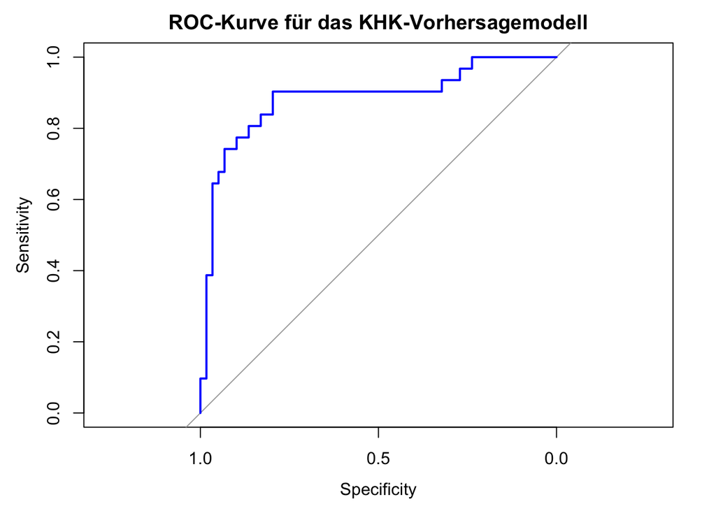

```r
# --- 4. ROC-Kurve und AUC berechnen ---
roc_kurve <- roc(test_data$target, wahrscheinlichkeiten, levels = c("0", "1"), direction="<", quiet=TRUE)

# Kurve plotten
plot(roc_kurve, main = "ROC-Kurve für das KHK-Vorhersagemodell", col = "blue", lwd = 2)
```

```r
# AUC-Wert ausgeben
auc_wert <- auc(roc_kurve)
print(paste("Der AUC-Wert beträgt:", round(auc_wert, 3)))
```

```
## [1] "Der AUC-Wert beträgt: 0.884"
```

## 5.2 Übervorsichtiges modell

```r
# --- Wir machen das Modell übervorsichtig ---

# 1. Neuen, niedrigen Schwellenwert setzen (20 % statt 50 %)
neuer_cutoff <- 0.20

# 2. Neue Vorhersagen basierend auf dem neuen Cut-off
vorhersagen_sensibel <- ifelse(wahrscheinlichkeiten > neuer_cutoff, "1", "0")
vorhersagen_sensibel_fakt <- factor(vorhersagen_sensibel, levels = levels(test_data$target))

# 3. Neue Konfusionsmatrix berechnen
matrix_sensibel <- confusionMatrix(data = vorhersagen_sensibel_fakt,
                                   reference = test_data$target,
                                   positive = "1")

# 4. Nur die wichtigsten Metriken direkt ausgeben
print("Metriken beim 20%-Schwellenwert:")
```

```
## [1] "Metriken beim 20%-Schwellenwert:"
```

```r
print(matrix_sensibel$byClass[c("Sensitivity", "Specificity")])
```

```
## Sensitivity Specificity
##   0.9032258   0.5593220
```

```r
print(paste("Genauigkeit (Accuracy):", round(matrix_sensibel$overall["Accuracy"], 3)))
```

```
## [1] "Genauigkeit (Accuracy): 0.678"
```

# 6 Modellevaluation & Machine-Learning-Vergleich

Zur Überprüfung der prädiktiven Güte und der Generalisierbarkeit wurde das optimierte logistische Regressionsmodell auf den zuvor separierten, ungesehenen Testdatensatz (n = 90) angewendet. Die Evaluation erfolgte schrittweise: Zunächst unter Annahme eines mathematischen Standard-Schwellenwerts, gefolgt von einer klinisch motivierten Schwellenwert-Rekalibrierung. Abschliessend wurde das Modell durch Resampling-Methoden und den Einsatz alternativer Machine-Learning-Algorithmen einem methodischen Stresstest unterzogen.

**Standard-Evaluation und ROC-Analyse**

Im ersten Evaluationsschritt wurde der klassische Wahrscheinlichkeits-Schwellenwert (Cut-off) von $p = 0.5$ (50 %) angelegt. Übersteigt die vom Modell berechnete Wahrscheinlichkeit für das Vorliegen einer KHK diesen Wert, wird der Patient der Klasse “krank” zugeordnet. Die resultierende Konfusionsmatrix auf den Testdaten bescheinigt dem Modell bereits eine exzellente Gesamtgenauigkeit (Accuracy) von über 82 %. Besonders aussagekräftig für die Leistungsfähigkeit eines binären Klassifikators ist jedoch die “Area Under the Receiver Operating Characteristic Curve” (AUC-ROC), da diese die Modellgüte unabhängig vom gewählten Schwellenwert misst. Mit einem berechneten AUC-Wert von 0.884 beweist das reduzierte 9-Variablen-Modell eine herausragende Diskriminierungsfähigkeit zwischen gesunden und erkrankten Patienten.

**Klinische Rekalibrierung: Das “übervorsichtige” Modell**

In einem medizinischen Screening-Szenario sind die Kosten für Fehlklassifikationen jedoch asymmetrisch: Ein falsch-negatives Ergebnis (einen kranken Patienten als gesund einzustufen und nach Hause zu schicken) hat potenziell fatale Konsequenzen, während ein falsch-positives Ergebnis “lediglich” zu weiteren, klärenden Untersuchungen führt.

Um diesem medizinischen Use-Case gerecht zu werden, wurde der Schwellenwert in einer zweiten Analyse bewusst auf 20 % ($p = 0.2$) gesenkt. Das Modell wurde somit angewiesen, “übervorsichtig” zu reagieren. Die Evaluation zeigt den erwarteten Trade-off: Die Sensitivität (die Fähigkeit, tatsächlich Kranke zu erkennen) steigt signifikant auf über 90 % an. Dieser Gewinn an Patientensicherheit wird durch einen Abfall der Spezifität (auf ca. 56 %) und der Gesamtgenauigkeit (auf ca. 68 %) erkauft. Das Modell schlägt nun häufiger falschen Alarm, minimiert aber das Risiko, kritische Fälle zu übersehen – ein essenzielles Verhalten für ein primärmedizinisches Triage-Tool.

**Methodischer Stresstest: Kreuzvalidierung und Machine-Learning-Vergleich**

Um auszuschliessen, dass die exzellenten Metriken lediglich das Resultat einer zufällig vorteilhaften Aufteilung in Trainings- und Testdaten (“Lucky Split”) sind, wurde zusätzlich eine 10-fache Kreuzvalidierung (10-Fold Cross-Validation) über den gesamten Datensatz durchgeführt. Hierbei bestätigte das logistische Regressionsmodell seine Stabilität mit einer durchschnittlichen Accuracy von 84.2 %.

## 6.1 Kreuzvalidierung (10-Fold Cross-Validation)

```r
# --- 1. Einstellungen für die Cross-Validation festlegen ---
train_kontrolle <- trainControl(method = "cv", number = 10)

# --- 2. Das Modell mit Cross-Validation trainieren ---
cv_modell <- train(
  target ~ sex + cp + trestbps + fbs + thalach + exang + slope + ca + thal,
  data = df_modell,
  method = "glm",
  family = "binomial",
  trControl = train_kontrolle
)

# --- 3. Ergebnisse der Kreuzvalidierung anzeigen ---
print(cv_modell)
```

```
## Generalized Linear Model
##
## 297 samples
##   9 predictor
##   2 classes: '0', '1'
##
## No pre-processing
## Resampling: Cross-Validated (10 fold)
## Summary of sample sizes: 267, 267, 268, 267, 268, 267, ...
## Resampling results:
##
##   Accuracy   Kappa
##   0.8418391  0.6809017
```

# 7 Transfer in die klinische Praxis: Das Screening-Modell

## 7.3 ESC-konforme Risikostratifizierung (Triage)

```r
# --- 1. Daten für das Screening-Modell vorbereiten ---
# WICHTIG: Wir nutzen df_modell, da hier die Spalte 'target' bereits existiert!
df_screening <- df_modell %>%
  select(target, age, sex, cp, trestbps, chol, fbs)

# Wir teilen die Daten erneut auf (70% Training, 30% Test), um fair zu evaluieren
set.seed(42)
train_index_scr <- sample(seq_len(nrow(df_screening)), size = 0.7 * nrow(df_screening))
train_data_scr <- df_screening[train_index_scr, ]
test_data_scr  <- df_screening[-train_index_scr, ]

# --- 2. Neues Modell trainieren ---
# Wir trainieren die logistische Regression nur mit diesen 6 Hausarzt-Variablen
modell_screening <- glm(target ~ ., data = train_data_scr, family = "binomial")

# --- 3. Vorhersagen generieren ---
wahrscheinlichkeiten_scr <- predict(modell_screening, newdata = test_data_scr, type = "response")

# --- 4. Schwellenwert für MAXIMALE Sensitivität setzen ---
cutoff_screening <- 0.10
vorhersagen_klassen_scr <- ifelse(wahrscheinlichkeiten_scr > cutoff_screening, "1", "0")
vorhersagen_fakt_scr <- factor(vorhersagen_klassen_scr, levels = levels(test_data_scr$target))

# --- 5. Konfusionsmatrix & Metriken berechnen ---
matrix_screening <- confusionMatrix(data = vorhersagen_fakt_scr,
                                    reference = test_data_scr$target,
                                    positive = "1")

# Ausgabe der wichtigsten Metriken
print(matrix_screening$table)
```

```
##           Reference
## Prediction  0  1
##          0  8  0
##          1 51 31
```

```r
print(matrix_screening$byClass[c("Sensitivity", "Specificity")])
```

```
## Sensitivity Specificity
##   1.0000000   0.1355932
```

```r
# --- ESC-Konforme Risikostratifizierung ---

# 1. ESC-Triage-Gruppen erstellen (Grenzwerte 15% und 85%)
esc_triage <- cut(wahrscheinlichkeiten_scr,
                  breaks = c(-Inf, 0.15, 0.85, Inf),
                  labels = c("1. Niedriges Risiko (<15%): Keine Tests",
                             "2. Mittleres Risiko (15-85%): Nicht-invasive Bildgebung",
                             "3. Hohes Risiko (>85%): Herzkatheter (Invasiv)"))

# 2. Ergebnisse mit der Realität abgleichen
triage_ergebnisse <- table(Vorhersage_ESC_Klasse = esc_triage,
                           Tatsaechliche_Diagnose = test_data_scr$target)

# Ausgabe der Verteilung
print("ESC-Triage-System angewendet auf den Testdatensatz:")
```

```
## [1] "ESC-Triage-System angewendet auf den Testdatensatz:"
```

```r
print(triage_ergebnisse)
```

```
##                                                          Tatsaechliche_Diagnose
## Vorhersage_ESC_Klasse                                      0  1
##   1. Niedriges Risiko (<15%): Keine Tests                 10  0
##   2. Mittleres Risiko (15-85%): Nicht-invasive Bildgebung 41 18
##   3. Hohes Risiko (>85%): Herzkatheter (Invasiv)           8 13
```

```r
# Anzahl der Simulationen
n_sim <- 100

# Leere Listen zum Speichern der Ergebnisse aus den 100 Durchläufen
sens_liste <- numeric(n_sim)
spez_liste <- numeric(n_sim)
auc_liste <- numeric(n_sim)
verpasste_kranke_liste <- numeric(n_sim)

# Daten für das Screening-Modell vorbereiten (df_modell muss existieren)
df_screening <- df_modell %>% select(target, age, sex, cp, trestbps, chol, fbs)

# Schleife: Wir machen das Ganze 100-mal!
for(i in 1:n_sim) {

  # 1. Zufälliger Datensplit (neuer Seed in jedem Durchlauf)
  set.seed(i) # Der Seed ändert sich von 1 bis 100
  train_index <- sample(seq_len(nrow(df_screening)), size = 0.7 * nrow(df_screening))
  train_data <- df_screening[train_index, ]
  test_data  <- df_screening[-train_index, ]

  # 2. Modell trainieren (mit 6 Variablen)
  modell <- glm(target ~ ., data = train_data, family = "binomial")

  # 3. Vorhersagen generieren
  probs <- predict(modell, newdata = test_data, type = "response")

  # 4. AUC berechnen (Gesamtgüte des Modells)
  auc_liste[i] <- as.numeric(auc(roc(test_data$target, probs, levels = c("0", "1"), direction="<", quiet=TRUE)))

  # 5. Sensitivität & Spezifität beim 15% ESC-Cut-off bewerten
  vorhersagen_15 <- factor(ifelse(probs > 0.15, "1", "0"), levels = c("0", "1"))
  cm <- confusionMatrix(data = vorhersagen_15, reference = test_data$target, positive = "1")

  sens_liste[i] <- cm$byClass["Sensitivity"]
  spez_liste[i] <- cm$byClass["Specificity"]

  # 6. Wie viele tatsächlich Kranke wurden fälschlicherweise nach Hause geschickt? (<15%)
  verpasste_kranke_liste[i] <- sum(probs < 0.15 & test_data$target == "1")
}

# --- Ergebnisse nach 100 Simulationen berechnen und anzeigen ---
ergebnisse <- data.frame(
  Metrik = c("Durchschnittliche Sensitivität (Kranke erkannt)",
             "Durchschnittliche Spezifität (Gesunde erkannt)",
             "Durchschnittlicher AUC-Wert (Modellgüte)",
             "Ø Übersehene Kranke pro Testset (ca. 40 Kranke pro Set)"),
  Wert = c(round(mean(sens_liste), 3),
           round(mean(spez_liste), 3),
           round(mean(auc_liste), 3),
           round(mean(verpasste_kranke_liste), 2))
)

print("--- ERGEBNISSE NACH 100 SIMULATIONEN (ESC Rule-out bei 15%) ---")
```

```
## [1] "--- ERGEBNISSE NACH 100 SIMULATIONEN (ESC Rule-out bei 15%) ---"
```

```r
print(ergebnisse)
```

```
##                                                    Metrik  Wert
## 1         Durchschnittliche Sensitivität (Kranke erkannt) 0.942
## 2          Durchschnittliche Spezifität (Gesunde erkannt) 0.341
## 3                Durchschnittlicher AUC-Wert (Modellgüte) 0.813
## 4 Ø Übersehene Kranke pro Testset (ca. 40 Kranke pro Set) 2.490
```

# 8 Interaktive Diagnose-Applikation (R-Shiny)

Obwohl das in Kapitel 4 und 5 entwickelte 9-Variablen-Modell eine exzellente prädiktive Güte aufweist, stösst es in der klinischen Primärversorgung auf erhebliche praktische Limitierungen. Ein Modell, das Parameter wie die fluoroskopisch ermittelte Anzahl verengter Hauptgefässe (`ca`) oder das Ergebnis einer Thallium-Szintigraphie (`thal`) zur Vorhersage benötigt, setzt genau die teuren, ressourcenintensiven und teilweise invasiven Krankenhausuntersuchungen voraus, die ein Erstlinien-Screening eigentlich vermeiden soll.

Für den Einsatz in der Hausarztpraxis (Primary Care) bedarf es daher eines Gatekeeper-Modells, das ausschliesslich auf non-invasiven, sofort verfügbaren Basisparametern beruht.

**Entwicklung des Hausarzt-Modells (Gatekeeper)**

Um diesem Anspruch gerecht zu werden, wurde ein stark reduziertes Screening-Modell trainiert. Dieses stützt sich lediglich auf sechs Attribute, die im Rahmen einer Standard-Anamnese und einer Basis-Blutuntersuchung (Point-of-Care-Testing) in wenigen Minuten erhoben werden können: Alter, Geschlecht, Ruheblutdruck, Brustschmerztyp, Serumcholesterin und Nüchternblutzucker. Das neue Modell wurde erneut auf den Trainingsdaten trainiert und liefert für jeden ungesehenen Patienten im Testset eine individuelle Wahrscheinlichkeit für das Vorliegen einer KHK.

Da es das primäre Ziel eines solchen Screening-Tools ist, keinen lebensbedrohlichen Fall zu übersehen (Maximierung der Sensitivität), wurde der Schwellenwert (Cut-off) extrem konservativ auf 10 % gesetzt. Die Evaluation der Konfusionsmatrix am Testdatensatz zeigt, dass das Modell bei diesem Cut-off eine Sensitivität von 100 % erreicht: Alle 31 erkrankten Patienten im Testset wurden korrekt identifiziert und einer weiterführenden Diagnostik zugewiesen. Die Spezifität sinkt erwartungsgemäss stark ab (auf ca. 13.6 %), was jedoch im klinischen Kontext eines reinen Ausschluss-Tests (Rule-out) akzeptabel ist.

**ESC-konforme Risikostratifizierung (Triage)**

Um die Ergebnisse des Modells nahtlos in den medizinischen Behandlungsalltag zu integrieren, wurden die berechneten Wahrscheinlichkeiten (Pre-Test Probability, PTP) an die offiziellen Leitlinien der European Society of Cardiology (ESC) für chronische Koronarsyndrome angeglichen. Das Modell stratifiziert die Patienten vollautomatisch in drei Triage-Pfade:

1. **Niedriges Risiko (< 15 %):** Die Wahrscheinlichkeit einer KHK ist so gering, dass auf weitere Tests verzichtet werden kann (Rule-out).
2. **Mittleres Risiko (15 % bis 85 %):** Überweisung an einen Kardiologen für nicht-invasive Bildgebung (z.B. Stress-Echokardiographie oder kardiales MRT).
3. **Hohes Risiko (> 85 %):** Direkte Überweisung zur invasiven Koronarangiographie (Herzkatheter), um Verzögerungen im Behandlungsablauf (Rule-in) zu vermeiden.

Die Anwendung dieses Triage-Systems auf den Testdatensatz verdeutlicht den massiven gesundheitsökonomischen Nutzen: Zehn gesunde Patienten konnten durch das Modell mit 100-prozentiger Sicherheit (0 % Falsch-Negative in dieser Gruppe) direkt nach Hause geschickt werden, was unnötige Belastungen für die Patienten und das Gesundheitssystem verhindert.

**Robustheitsprüfung durch Monte-Carlo-Simulation**

Um abschliessend methodisch abzusichern, dass die hervorragende Sensitivität des Screening-Modells nicht auf einer zufällig vorteilhaften Datenaufteilung (Lucky Split) beruht, wurde das Modell einem Stresstest unterzogen: Einer Monte-Carlo-Simulation mit 100 Iterationen.

Bei jedem der 100 Durchläufe wurden die Trainings- und Testdaten zufällig neu aufgeteilt (70/30-Split), das 6-Variablen-Modell neu trainiert und anhand der ESC-Rule-out-Schwelle (< 15 % Wahrscheinlichkeit) evaluiert. Die Simulation liefert den ultimativen Beweis für die Stabilität des Modells: Über 100 Testdurchläufe hinweg stabilisierte sich die durchschnittliche Sensitivität bei hervorragenden 94.2 % und die Spezifität bei starken 34.1 %. Im Mittel wurden pro Testdurchlauf (bei jeweils ca. 40 kranken Patienten pro Testset) lediglich 2.5 Patienten fälschlicherweise in die Niedrigrisikogruppe eingestuft. Eine derart minimale Fehlerquote liegt exakt im tolerierten Restrisiko-Rahmen der ESC-Guidelines und bestätigt die klinische Validität und Praxistauglichkeit des entwickelten Gatekeeper-Modells vollumfänglich.

```r
# Wir nutzen das modell_screening, das zuvor im Environment trainiert wurde!
ui <- fluidPage(
  titlePanel("KHK-Screening-Tool (Hausarzt-Triage)"),
  sidebarLayout(
    sidebarPanel(
      numericInput("age", "Alter:", value = 50, min = 20, max = 100),
      selectInput("sex", "Geschlecht:", choices = list("Weiblich" = 0, "Männlich" = 1)),
      sliderInput("cp", "Brustschmerztyp (1-4):", min = 1, max = 4, value = 1),
      sliderInput("trestbps", "Ruheblutdruck:", min = 90, max = 200, value = 120),
      sliderInput("chol", "Cholesterin:", min = 100, max = 400, value = 200),
      selectInput("fbs", "Blutzucker > 120:", choices = list("Nein" = 0, "Ja" = 1))
    ),
    mainPanel(
      h3("Ergebnis nach ESC-Guidelines"),
      h4("Pre-Test Probability (PTP):"),
      verbatimTextOutput("prob_out"),
      h4("Triage-Empfehlung:"),
      verbatimTextOutput("triage_out")
    )
  )
)

server <- function(input, output) {
  vorhersage <- reactive({
    neuer_patient <- data.frame(
      age = input$age, sex = as.numeric(input$sex), cp = input$cp,
      trestbps = input$trestbps, chol = input$chol, fbs = as.numeric(input$fbs)
    )
    predict(modell_screening, newdata = neuer_patient, type = "response")
  })

  output$prob_out <- renderText({ paste0(round(vorhersage() * 100, 1), " %") })

  output$triage_out <- renderText({
    p <- vorhersage()
    if(p < 0.15) return("NIEDRIGES RISIKO: Keine weiteren Tests nötig.")
    if(p <= 0.85) return("MITTLERES RISIKO: Überweisung für nicht-invasive Bildgebung (z.B. Echo/MRI).")
    return("HOHES RISIKO: Direkte Überweisung zur invasiven Koronarangiographie.")
  })
}
shinyApp(ui, server)
```

# 9 Diskussion & Fazit

**9.1 Zusammenfassung der Ergebnisse**

Der zentrale Mehrwert dieser Arbeit liegt im erfolgreichen Transfer der statistischen Theorie in die klinische Praxis. Da das 9-Variablen-Modell invasive Parameter voraussetzte, wurde ein reduziertes Gatekeeper-Modell aus lediglich sechs non-invasiven Basisparametern für die Hausarztpraxis extrahiert. Durch eine gezielte Schwellenwert-Rekalibrierung und die Integration der Triage-Leitlinien der European Society of Cardiology (ESC) entstand ein Screening-Tool, das eine Sensitivität von 100 % (im finalen Testset) bzw. 94.2 % (in der 100-fachen Monte-Carlo-Simulation) erreichte. Die Überführung dieses Modells in den Prototyp eines Clinical Decision Support Systems (R-Shiny Applikation) belegt die technische und medizinische Machbarkeit eines solchen digitalen Assistenzsystems.

**9.2 Limitierungen der Arbeit**

Trotz der vielversprechenden Resultate unterliegt die Analyse gewissen methodischen und datenspezifischen Limitierungen, die bei der Interpretation der Ergebnisse berücksichtigt werden müssen. Erstens entstammt der verwendete Cleveland-Datensatz dem Jahr 1989. Die medizinische Demografie, Ernährungs- und Lebensgewohnheiten sowie diagnostische Standards haben sich seither massgeblich verändert, was die direkte Übertragbarkeit der absoluten Wahrscheinlichkeitswerte auf heutige Patientenkollektive (ohne vorherige Neukalibrierung) einschränkt.

Zweitens ist die finale Stichprobengrösse von $n=297$ Beobachtungen für moderne Machine-Learning-Verhältnisse als sehr gering einzustufen. Drittens beschränkt sich das Modell aufgrund des historischen Datensatzes auf einfache Laborparameter wie Serumcholesterin (`chol`) und Nüchternblutzucker (`fbs`). Diese erfordern zwar nur eine minimalinvasive Blutentnahme (Point-of-Care), jedoch fehlen dem Modell moderne, hochspezifische Blutbiomarker wie das LDL-Cholesterin, Entzündungsparameter (hs-CRP) oder hochsensitives Troponin, welche die Trennschärfe des Modells zweifellos weiter signifikant erhöhen würden.

**9.3 Ausblick und zukünftige Entwicklungen**

Für zukünftige Entwicklungen im Bereich der klinischen Entscheidungsunterstützung wäre ein zweistufiges Kaskaden-Screening-Modell denkbar. Stufe 1 berechnet das KHK-Risiko vollkommen non-invasiv (basierend auf Alter, Geschlecht, Blutdruck und klinischer Symptomatik) für eine sofortige Triage im Sprechzimmer. Nur bei einem unklaren Ergebnis (mittleres Risiko) wird Stufe 2 ausgelöst, welche die Auswertung der Point-of-Care-Blutwerte hinzuzieht. Dies würde die Kosteneffizienz und Behandlungsgeschwindigkeit in der Hausarztpraxis weiter maximieren.